# HW5

Hunter Schwartz

# 1.

```r
hayfever <- read.table("CH19PR14.txt")

relief <- hayfever$V1
trtA <- as.factor( hayfever$V2 )
trtB <- as.factor( hayfever$V3 )
```

# 2.

```r
model <- aov(relief ~ trtA * trtB)

# -- Note: the following are statistics named after the parameter they estimate

muij <- tapply(relief, list(trtA, trtB), FUN=mean)  # muij[trtA level, trtB level]
mui. <- apply(muij, MARGIN=1, FUN=mean)
mu.j <- apply(muij, MARGIN=2, FUN=mean)
mu.. <- mean(muij)

alphai <- mui. - mu..
betaj <- mu.j - mu..
```

# 3.

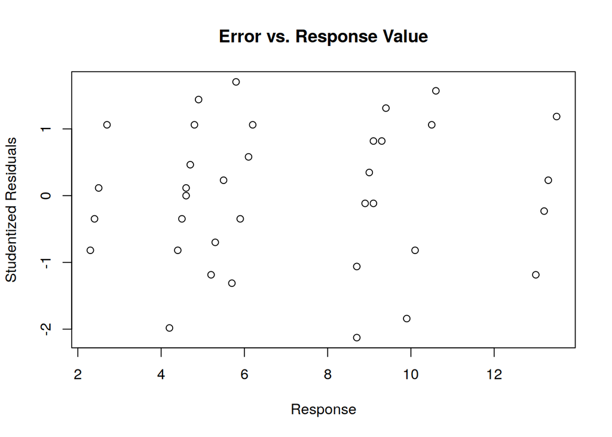

```r
plot(relief, rstudent(model), xlab="Response", ylab="Studentized Residuals",
     main="Error vs. Response Value")
```

This plot is intended to check whether the variance of the error terms is constant across all values of the response variable. The residuals appear to have consistent variance here, although they do seem skewed slightly towards the negative direction.

# 4.

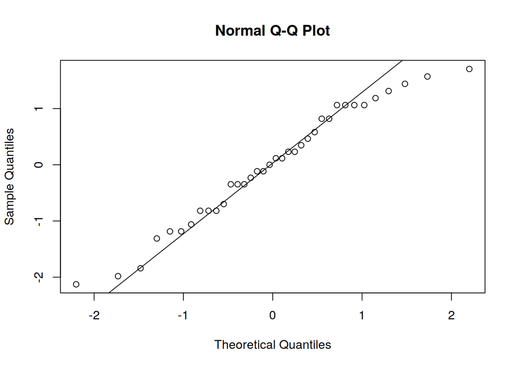

```r
qqnorm( rstudent(model) )
qqline( rstudent(model) )
```

```r
shapiro.test( residuals(model) )
```

```
##
##  Shapiro-Wilk normality test
##
## data:  residuals(model)
## W = 0.96509, p-value = 0.3069
```

The residuals seem slightly off here, as before, however the Shapiro test for normality concludes that we may treat the residuals as if they are distributed normally (*p > .3*).

# 5.

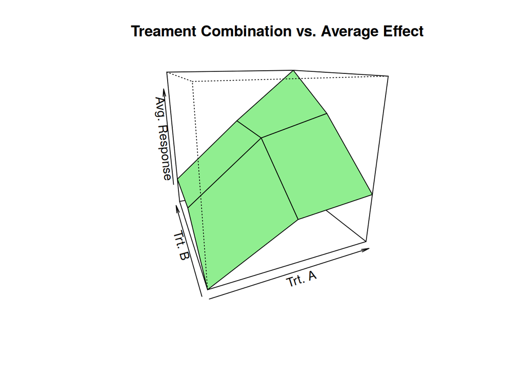

```r
persp( as.numeric(levels(trtA)), as.numeric(levels(trtB)), muij, theta=-23,
       phi=18, xlab="Trt. A", ylab="Trt. B", zlab="Avg. Response",
       main="Treament Combination vs. Average Effect", col="lightgreen")
```

There appears to be a very clear increase of the response value associated with increasing the level of treatment A and for treatment B.

# 6.

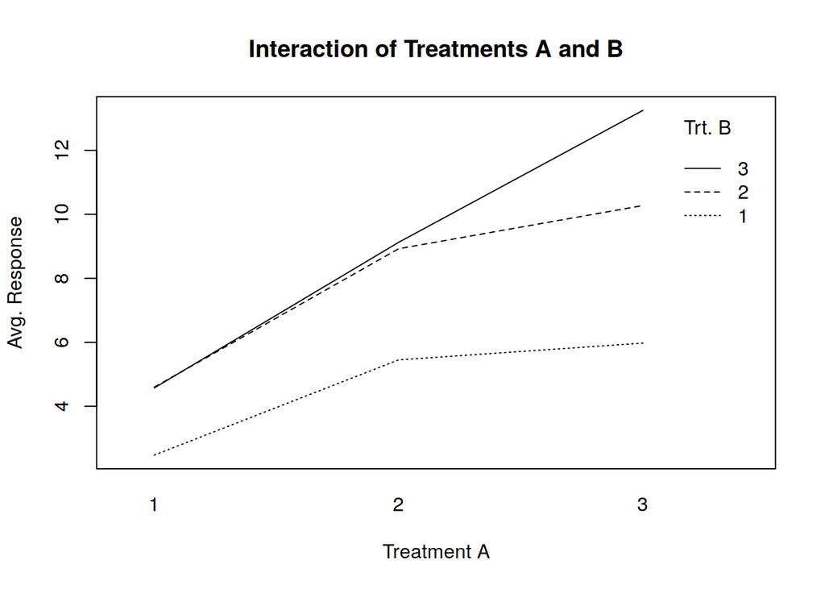

```r
interaction.plot(trtA, trtB, response=relief, xlab="Treatment A", ylab="Avg. Response",
                 trace.label="Trt. B", main="Interaction of Treatments A and B")
```

This plot suggests the presence of interaction effects, since the lines are clearly not parallel to one another, meaning the effect of treatment B depends on the level of treatment A.

# 7.

```r
anova(model)
```

```
## Analysis of Variance Table
##
## Response: relief
##           Df  Sum Sq Mean Sq F value    Pr(>F)
## trtA       2 220.020 110.010 1827.86 < 2.2e-16 ***
## trtB       2 123.660  61.830 1027.33 < 2.2e-16 ***
## trtA:trtB  4  29.425   7.356  122.23 < 2.2e-16 ***
## Residuals 27   1.625   0.060
## ---
## Signif. codes:  0 '***' 0.001 '**' 0.01 '*' 0.05 '.' 0.1 ' ' 1
```

# 8.

The results from the ANOVA table above give the results for the $F$-test for interaction, and since the $p$-value is so low, at any reasonable level $\alpha$ we reject the null hypothesis and conclude the interaction plays a significant role in our results.

# 9.

```r
n <- 36
r <- 9
alpha <- .10

cc.scheffe <- sqrt( (r - 1) * qf((1 - alpha), (r - 1), (n - r)) )

confints <- matrix(nrow=6, ncol=2)
rownames(confints) <- c("L1", "L2", "L3", "L4", "L5", "L6")
colnames(confints) <- c("Lower", "Upper")

mse <- anova(model)$`Mean Sq`[4]
L1.hat <- (muij[1,2] + muij[1,3]) / 2 - muij[1,1]
L1.se <- mse * (1/4 + 1/4 + 1)
L2.hat <- (muij[2,2] + muij[2,3]) / 2 - muij[2,1]
L2.se <- mse * (1/4 + 1/4 + 1)
L3.hat <- (muij[3,2] + muij[3,3]) / 2 - muij[3,1]
L3.se <- mse * (1/4 + 1/4 + 1)
L4.hat <- L2.hat - L1.hat
L4.se <- L2.se + L1.se
L5.hat <- L3.hat - L1.hat
L5.se <- L3.se + L1.se
L6.hat <- L3.hat - L2.hat
L6.se <- L3.se + L2.se

confints[1,1] <- L1.hat - L1.se * cc.scheffe
confints[1,2] <- L1.hat + L1.se * cc.scheffe
confints[2,1] <- L2.hat - L2.se * cc.scheffe
confints[2,2] <- L2.hat + L2.se * cc.scheffe
confints[3,1] <- L3.hat - L3.se * cc.scheffe
confints[3,2] <- L3.hat + L3.se * cc.scheffe
confints[4,1] <- L4.hat - L4.se * cc.scheffe
confints[4,2] <- L4.hat + L4.se * cc.scheffe
confints[5,1] <- L5.hat - L5.se * cc.scheffe
confints[5,2] <- L5.hat + L5.se * cc.scheffe
confints[6,1] <- L6.hat - L6.se * cc.scheffe
confints[6,2] <- L6.hat + L6.se * cc.scheffe

print(confints)
```

```
##        Lower    Upper
## L1 1.7596918 2.465308
## L2 3.2221918 3.927808
## L3 5.4346918 6.140308
## L4 0.7568835 2.168116
## L5 2.9693835 4.380616
## L6 1.5068835 2.918116
```